# Assignment 3 - Yelp Text Mining, Sentiment Analyses

Lauren Sansone, Lina Quiceno Bejarano, Joshua Pollack

### **Assignment 3 - Yelp Text Mining, Sentiment Analyses**

### **Lauren Sansone, Lina Quiceno Bejarano, Joshua Pollack**

```r
# the data file uses ';' as delimiter, and for this we use the read_csv2 function
resReviewsData <- read_csv2('yelpRestaurantReviews_sample.csv')
```

### **Exploring the Data**

1. **How are star ratings distributed? How will you use the star ratings to obtain a label indicating ‘positive’ or ‘negative’ – explain using the data, graphs, etc.?**

The Yelp restaurant review ratings are given as one through five stars. The distribution show 5 stars ratings are the ones with the highest number of ratings. Out of a total of 47,495 reviews, the five-star reviews have the most with 16,091 ratings. There are the least two-star reviews with 4,757 ratings.

We are going to consider reviews with 1 to 2 stars as negative, and 4 to 5 stars as positive

```r
#number of reviews by star-rating
resReviewsData %>% group_by(stars) %>% count()
```

### **Organizing the Data**

```r
#The reviews are from various locations -- check
resReviewsData %>%   group_by(state) %>% tally() %>% view()
 #Can also check the postal-codes`

#keep only the those reviews from 5-digit postal-codes
rrData <- resReviewsData %>% filter(str_detect(postal_code, "^[0-9]{1,5}"))
```

Use tidytext for tokenization, removing stopworks, stemming/lemmatization, etc.

```r
#How many tokens?
rrTokens %>% distinct(word) %>% dim()
```

```
## [1] 70321     1
```

```r
#remove stopwords
rrTokens <- rrTokens %>% anti_join(stop_words)
 #compare with earlier - what fraction of tokens were stopwords?
rrTokens %>% distinct(word) %>% dim()
```

```
## [1] 69622     1
```

```r
 (69622*100)/70321
```

```
## [1] 99.00599
```

A table was created to view the top ten words used in reviews. “Food” is the most frequently used word at 25,240 times. “Service” is the second most used word at 12,380 times.

Both of the words “food” and “service” are general and do not provide much insight into a positive or negative rating. As such, the data was explored more to obtain a better approach to determining positive or negative ratings.

```r
#count the total occurrences of differet words, & sort by most frequent
rrTokens %>% count(word, sort=TRUE) %>% top_n(10)
```

| word | n |
| --- | --- |
| food | 25240 |
| service | 12380 |
| time | 9419 |
| chicken | 7700 |
| restaurant | 7245 |
| nice | 5969 |
| pizza | 5800 |
| delicious | 5571 |
| love | 5526 |
| menu | 5352 |

We removed words that occur in 100 reviews or less. We also looked at the most used words and filtered out words that occur in 6,000 reviews or more. This removed some of the overly used general words such as “food”, “service”, “time” and “chicken”. This stopped filtering at the first positive word of “nice” at 5,969 uses.

```r
#Are there some words that occur in a large majority of reviews, or which are there in very few reviews?   Let's remove the words which are not present in at least 10 reviews
rareWords <-rrTokens %>% count(word, sort=TRUE) %>% filter(n<100)
xx<-anti_join(rrTokens, rareWords)
```

```r
rrTokens <- xx
```

```r
#Remove the words which are present in over 6000 reviews
popWords <-rrTokens %>% count(word, sort=TRUE) %>% filter(n>6000)
xx<-anti_join(rrTokens, popWords)
```

```r
#you willl see that among the least frequently occurring words are those starting with or including numbers (as in 6oz, 1.15,...).  To remove these

xx2<- xx %>% filter(str_detect(word,"[0-9]")==FALSE)
```

```r
#the variable xx, xx2 are for checking ....if this is what we want, set the rrTokens to the reduced set of words.  And you can remove xx, xx2 from the environment.

rrTokens<- xx2
```

### **Do star ratings have any relation to ‘funny’, ‘cool’, ‘useful’? Is this what you expected?**

Each Yelp review can be voted as “funny”, “cool”, or “useful”. We used a gg-plot to view the number of times the reviews were voted “funny”, “cool”, or “useful” by star-ratings.

It was expected to see a clear pattern of cool in stars 4 and 5 but the pattern is not as clear as expected. Even tough we find that as the number of people in crease the rating of 4 and 5 stars increase.

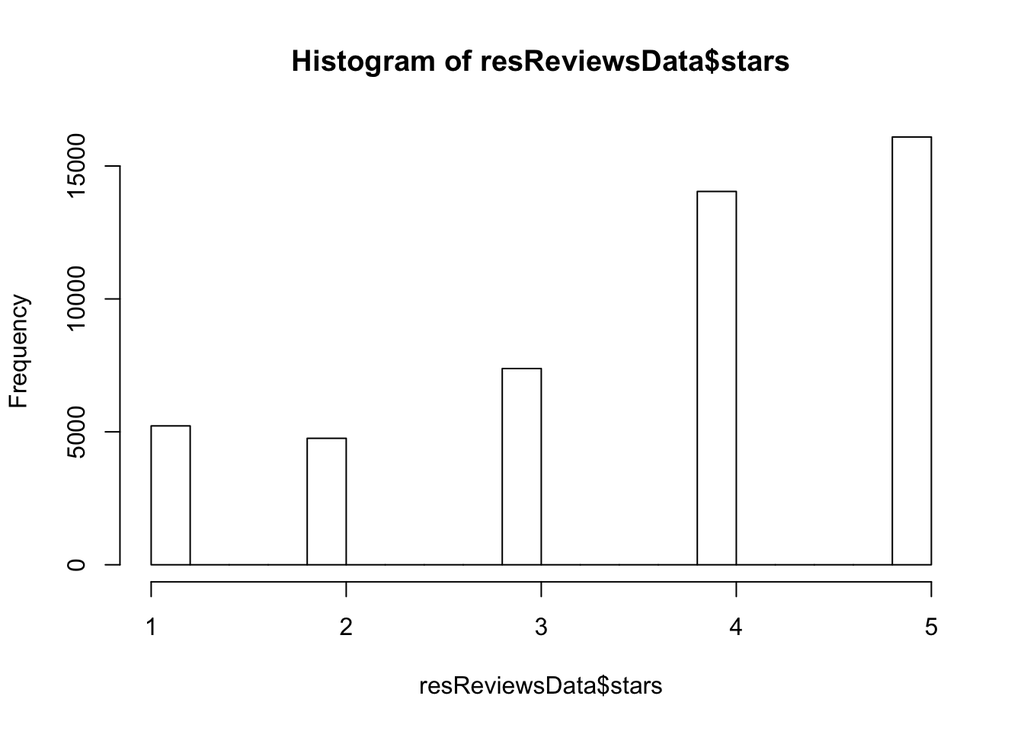

```r
hist(resReviewsData$stars)
```

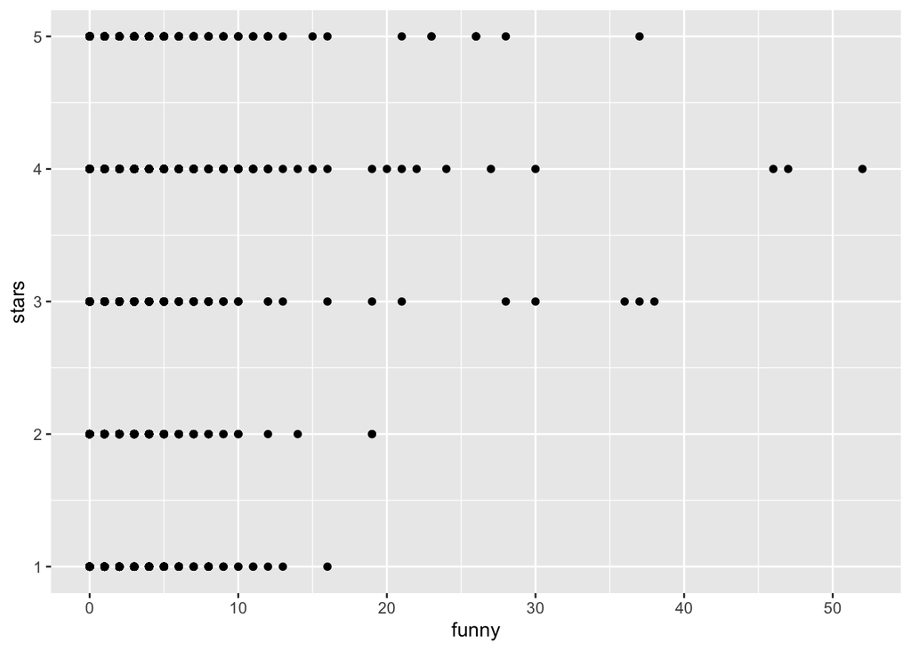

```r
ggplot(resReviewsData, aes(x= funny, y=stars)) +geom_point()
```

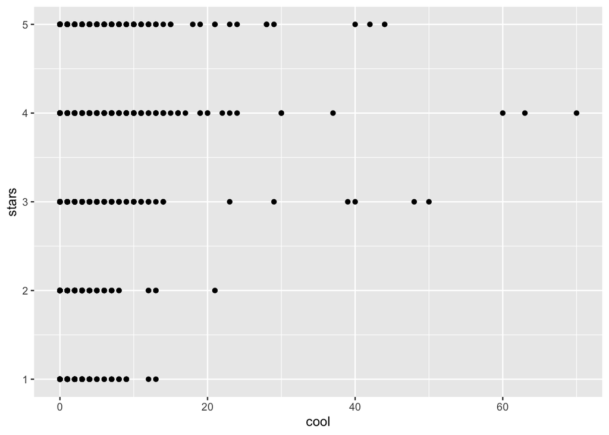

```r
ggplot(resReviewsData, aes(x= cool, y=stars)) +geom_point()
```

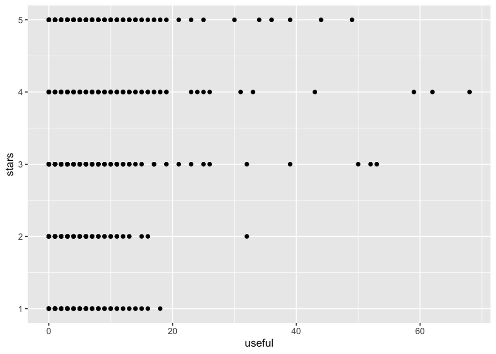

```r
ggplot(resReviewsData, aes(x= useful, y=stars)) +geom_point()
```

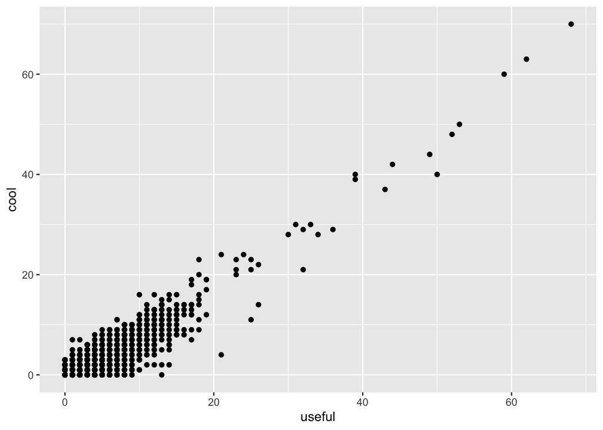

```r
ggplot(resReviewsData, aes(x= useful, y=cool)) +geom_point()
```

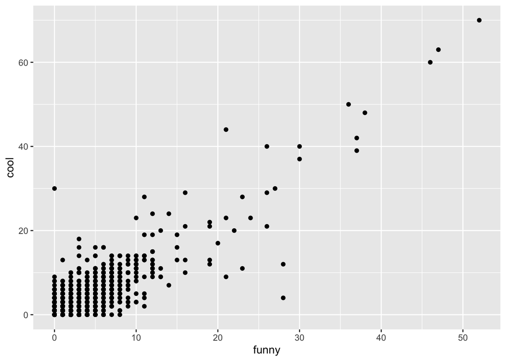

```r
ggplot(resReviewsData, aes(x= funny, y=cool)) +geom_point()
```

### **b) What are some words indicative of positive and negative sentiment? (One approach is to determine the average star rating for a word based on star ratings of documents where the word occurs).**

To gain some insight into words indicative of positive or negative sentiment, we calculated the average star rating of the review associated with each word. Then, we looked at the proportion of each word that appears per star rating.

Analyze words by star ratings

```r
#Check words by star rating of reviews
rrTokens %>% group_by(stars) %>% count(word, sort=TRUE)
```

| stars | word | n |
| --- | --- | --- |
| 5 | delicious | 3034 |
| 5 | love | 3001 |
| 5 | amazing | 2615 |
| 5 | friendly | 2213 |
| 4 | nice | 2118 |
| 5 | pizza | 2025 |
| 5 | fresh | 1939 |
| 5 | nice | 1880 |
| 4 | delicious | 1847 |
| 4 | menu | 1796 |

[output cut: 9422 more lines]

```r
#or...
rrTokens %>% group_by(stars) %>% count(word, sort=TRUE) %>% arrange(desc(stars)) %>% view()
```

```r
#proportion of word occurrence by star ratings
ws <- rrTokens %>% group_by(stars) %>% count(word, sort=TRUE)
ws<-  ws %>% group_by(stars) %>% mutate(prop=n/sum(n))
```

```r
#check the proportion of 'love' among reviews with 1,2,..5 stars
ws %>% filter(word=='love')
```

| stars | word | n | prop |
| --- | --- | --- | --- |
| 5 | love | 3001 | 0.010466876 |
| 4 | love | 1543 | 0.005716530 |
| 3 | love | 504 | 0.003426590 |
| 2 | love | 290 | 0.002986612 |
| 1 | love | 188 | 0.001973546 |

```r
#what are the most commonly used words by star rating
ws %>% group_by(stars) %>% arrange(stars, desc(prop)) %>% view()
```

```r
#to see the top 20 words by star ratings
ws %>% group_by(stars) %>% arrange(stars, desc(prop)) %>% filter(row_number()<=20) %>% view()
```

We created a plot with the distribution of the proportion of words in each start to make it easier the interpretation on how they are distributed. As we mention in our answer of question 1 A, starts 1 and 2 are related to bad labels and 5 and 4 to good ones. Here we can see that words as awesome and amazing are only in the 5 starts category, which suggest thy have a relation with good sentiment. While the word worst is only present in 8 the 1 star rating. These words does make sense in the context of user reviews being considered as we are considering the extreme cases of reviews (1 and 5 stars) for restaurants.

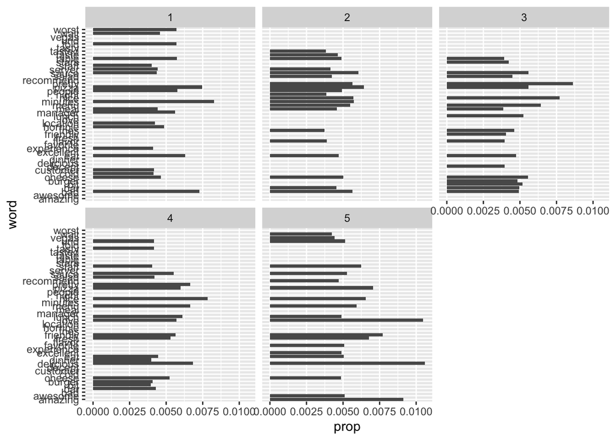

```r
#To plot this
ws %>% group_by(stars) %>% arrange(stars, desc(prop)) %>% filter(row_number()<=20) %>% ggplot(aes(word, prop))+geom_col()+coord_flip()+facet_wrap((~stars))
```

A higher score appears more often in higher reviews and lower scores appear in lower reviews, this table give us a more general sense of the positive and negative terms in the reviews.

```r
#Can we get a sense of which words are related to higher/lower star raings in general?
#One approach is to calculate the average star rating associated with each word - can sum the star ratings associated with reviews where each word occurs in.  Can consider the proportion of each word among reviews with a star rating.
xx<- ws %>% group_by(word) %>% summarise(totWS=sum(stars*prop))

#What are the 20 words with highest and lowest star rating
xx %>% top_n(20)
```

| word | totWS |
| --- | --- |
| amazing | 0.06693092 |
| bar | 0.06145768 |
| cheese | 0.07651119 |
| delicious | 0.09367925 |
| eat | 0.07291894 |
| fresh | 0.07211557 |
| friendly | 0.08007458 |
| love | 0.09342704 |
| lunch | 0.07486791 |
| meal | 0.06099206 |

[output cut: 10 more lines]

```r
xx %>% top_n(-20)
```

| word | totWS |
| --- | --- |
| businesses | 0.001676381 |
| canned | 0.001627519 |
| chowder | 0.001663155 |
| costs | 0.001677283 |
| doch | 0.001632543 |
| foot | 0.001635541 |
| health | 0.001658032 |
| heck | 0.001611361 |
| kein | 0.001629232 |
| messed | 0.001654823 |

[output cut: 10 more lines]

### c) How many matching terms are there for each of the dictionaries?

### Consider using the dictionary based positive and negative terms to predict sentiment (positive or negative based on star rating) . One approach for this is: using each dictionary, obtain an aggregated positiveScore and a negativeScore for each review; for the AFINN dictionary, an aggregate positivity score can be obtained for each review.

### Describe how you obtain predictions based on aggregated scores. Are you able to predict review sentiment based on these aggregated scores, and how do they perform? Does any dictionary perform better?

Stemming and Lemmatization

```r
rrTokens_stem<-rrTokens %>%  mutate(word_stem = SnowballC::wordStem(word))
rrTokens_lemm<-rrTokens %>%  mutate(word_lemma = textstem::lemmatize_words(word))
   #Check the original words, and their stemmed-words and word-lemmas
```

Term-frequency, tf-idf

```r
#tokenize, remove stopwords, and lemmatize (or you can use stemmed words instead of lemmatization)
rrTokens<-rrTokens %>%  mutate(word = textstem::lemmatize_words(word))
```

```r
#Or, to you can tokenize, remove stopwords, lemmatize  as
#rrTokens <- resReviewsData %>% select(review_id, stars, text, ) %>% unnest_tokens(word, text) %>%  anti_join(stop_words) %>% mutate(word = textstem::lemmatize_words(word))
```

```r
#We may want to filter out words with less than 3 characters and those with more than 15 characters
rrTokens<-rrTokens %>% filter(str_length(word)<=3 | str_length(word)<=15)

rrTokens<- rrTokens %>% group_by(review_id, stars) %>% count(word)
```

```r
#count total number of words by review, and add this in a column
totWords<-rrTokens  %>% group_by(review_id) %>%  count(word, sort=TRUE) %>% summarise(total=sum(n))
xx<-left_join(rrTokens, totWords)
  # now n/total gives the tf values
xx<-xx %>% mutate(tf=n/total)
head(xx)
```

| review_id | stars | word | n | total | tf |
| --- | --- | --- | --- | --- | --- |
| __-LvVFplBRmVu4o2MQZOw | 5 | bacon | 1 | 19 | 0.05263158 |
| __-LvVFplBRmVu4o2MQZOw | 5 | buy | 1 | 19 | 0.05263158 |
| __-LvVFplBRmVu4o2MQZOw | 5 | choose | 1 | 19 | 0.05263158 |
| __-LvVFplBRmVu4o2MQZOw | 5 | fresh | 1 | 19 | 0.05263158 |
| __-LvVFplBRmVu4o2MQZOw | 5 | friendly | 1 | 19 | 0.05263158 |
| __-LvVFplBRmVu4o2MQZOw | 5 | fun | 1 | 19 | 0.05263158 |

```r
#We can use the bind_tfidf function to calculate the tf, idf and tfidf values
# (https://www.rdocumentation.org/packages/tidytext/versions/0.2.2/topics/bind_tf_idf)
rrTokens<-rrTokens %>% bind_tf_idf(word, review_id, n)
head(rrTokens)
```

| review_id | stars | word | n | tf | idf | tf_idf |
| --- | --- | --- | --- | --- | --- | --- |
| __-LvVFplBRmVu4o2MQZOw | 5 | bacon | 1 | 0.04347826 | 3.468686 | 0.15081244 |
| __-LvVFplBRmVu4o2MQZOw | 5 | buy | 1 | 0.04347826 | 4.185753 | 0.18198928 |
| __-LvVFplBRmVu4o2MQZOw | 5 | choose | 1 | 0.04347826 | 3.638720 | 0.15820521 |
| __-LvVFplBRmVu4o2MQZOw | 5 | fresh | 1 | 0.04347826 | 2.284730 | 0.09933611 |
| __-LvVFplBRmVu4o2MQZOw | 5 | friendly | 1 | 0.04347826 | 2.058143 | 0.08948446 |
| __-LvVFplBRmVu4o2MQZOw | 5 | fun | 1 | 0.04347826 | 3.526700 | 0.15333480 |

Sentiment analysis using the 3 sentiment dictionaries available with tidytext (use library(textdata)) AFINN http://www2.imm.dtu.dk/pubdb/views/publication_details.php?id=6010 bing https://www.cs.uic.edu/~liub/FBS/sentiment-analysis.html nrc http://saifmohammad.com/WebPages/NRC-Emotion-Lexicon.htm

```r
library(textdata)

#take a look at the words in the sentiment dictionaries
get_sentiments("bing") %>% view()
```

```r
#if we want to retain only the words which match the sentiment dictionary, do an inner-join
rrSenti_bing<- rrTokens %>% inner_join(get_sentiments("bing"), by="word")
```

### How many matching terms are there for each of the dictionaries?

**For the bing dictionary we found a total of 258 total matching words**

```r
bingMatchUniqueWords <- unique(rrSenti_bing$word)
```

```r
#Analyze Which words contribute to positive/negative sentiment - we can count the ocurrences of positive/negative sentiment words in the reviews
xx<-rrSenti_bing %>% group_by(word, sentiment) %>% summarise(totOcc=sum(n)) %>% arrange(sentiment, desc(totOcc))
```

```r
#negate the counts for the negative sentiment words
xx<- xx %>% mutate (totOcc=ifelse(sentiment=="positive", totOcc, -totOcc))
```

```r
#the most positive and most negative words
xx<-ungroup(xx)
xx %>% top_n(25)
```

| word | sentiment | totOcc |
| --- | --- | --- |
| love | positive | 7461 |
| nice | positive | 5969 |
| delicious | positive | 5571 |
| friendly | positive | 4715 |
| pretty | positive | 4623 |
| fresh | positive | 4302 |
| amaze | positive | 3931 |
| recommend | positive | 3256 |
| enjoy | positive | 3069 |
| favorite | positive | 2975 |

[output cut: 15 more lines]

```r
xx %>% top_n(-25)
```

| word | sentiment | totOcc |
| --- | --- | --- |
| bad | negative | -4108 |
| die | negative | -3311 |
| disappoint | negative | -2245 |
| hard | negative | -1276 |
| cheap | negative | -1268 |
| cold | negative | -1250 |
| wrong | negative | -1149 |
| slow | negative | -1047 |
| bland | negative | -989 |
| miss | negative | -936 |

[output cut: 15 more lines]

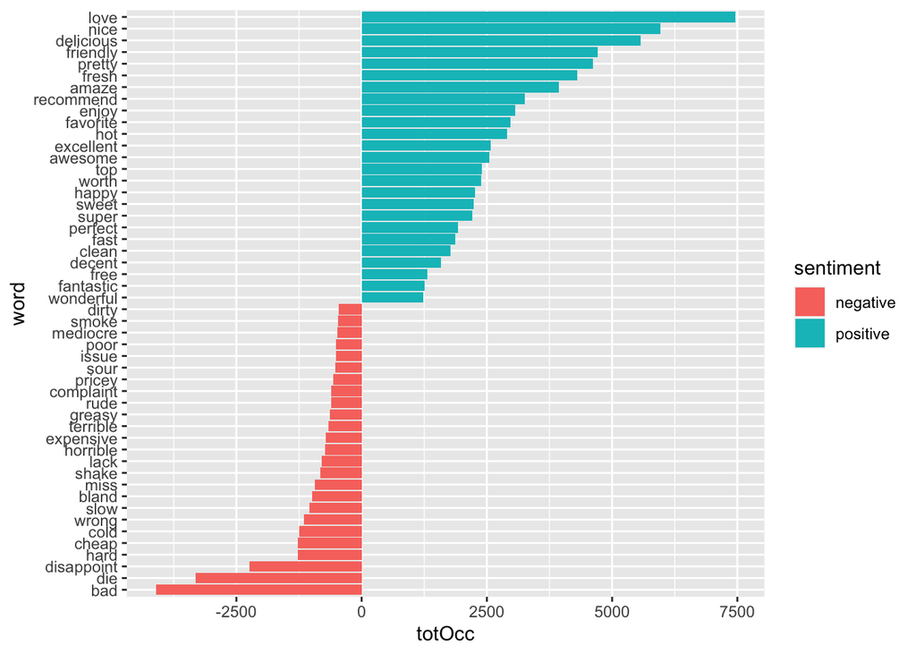

```r
#or, with a better reordering of words
rbind(top_n(xx, 25), top_n(xx, -25)) %>% mutate(word=reorder(word,totOcc)) %>% ggplot(aes(word, totOcc, fill=sentiment)) +geom_col()+coord_flip()
```

```r
#Q - does this 'make sense'?  Do the different dictionaries give similar results; do you notice much difference?
```

```r
#with "nrc" dictionary
rrSenti_nrc<-rrTokens %>% inner_join(get_sentiments("nrc"), by="word") %>% group_by (review_id, word, sentiment, stars) %>% summarise(totOcc=sum(n)) %>% arrange(sentiment, desc(totOcc))
#we added review_id, stars
```

### How many matching terms are there for each of the dictionaries?

**For the NRC dictionary we found a total of 371 total matching words**

Nrc Match Unique Words

```r
nrcMatchUniqueWords <- unique(rrSenti_nrc$word)
```

```r
#How many words for the different sentiment categories
rrSenti_nrc %>% group_by(sentiment) %>% summarise(count=n(), sumn=sum(totOcc))
```

|  | sentiment | count | sumn |
| --- | --- | --- | --- |
| 1 | anger | 21381 | 24488 |
| 2 | anticipation | 57399 | 65711 |
| 3 | disgust | 17911 | 19965 |
| 4 | fear | 16742 | 20985 |
| 5 | joy | 72125 | 83704 |
| 6 | negative | 53208 | 63341 |
| 7 | positive | 139520 | 160670 |
| 8 | sadness | 22505 | 27032 |
| 9 | surprise | 26434 | 29306 |
| 10 | trust | 70122 | 79031 |

```r
#Suppose you want   to consider  {anger, disgust, fear sadness, negative} to denote 'bad' reviews, and {positive, joy, anticipation, trust} to denote 'good' reviews
xx<-rrSenti_nrc %>% mutate(goodBad=ifelse(sentiment %in% c('anger', 'disgust', 'fear', 'sadness', 'negative'), -totOcc, ifelse(sentiment %in% c('positive', 'joy', 'anticipation', 'trust'), totOcc, 0)))
```

```r
xx<-ungroup(xx)
top_n(xx, 10)
```

| review_id | word | sentiment | stars | totOcc | goodBad |
| --- | --- | --- | --- | --- | --- |
| GKpvEZM8KK7QLfj4CRe52g | pretty | anticipation | 2 | 15 | 15 |
| evUjGH1ughLBAuCpVCao-g | beer | joy | 4 | 15 | 15 |
| GKpvEZM8KK7QLfj4CRe52g | pretty | joy | 2 | 15 | 15 |
| UwSztMEbUMgcywewKIr6gQ | beer | joy | 2 | 15 | 15 |
| kMibxQibl_GqCoGmST9fxw | beer | joy | 5 | 13 | 13 |
| evUjGH1ughLBAuCpVCao-g | beer | positive | 4 | 15 | 15 |
| GKpvEZM8KK7QLfj4CRe52g | pretty | positive | 2 | 15 | 15 |
| UwSztMEbUMgcywewKIr6gQ | beer | positive | 2 | 15 | 15 |
| kMibxQibl_GqCoGmST9fxw | beer | positive | 5 | 13 | 13 |
| GKpvEZM8KK7QLfj4CRe52g | pretty | trust | 2 | 15 | 15 |

```r
top_n(xx, -10)
```

| review_id | word | sentiment | stars | totOcc | goodBad |
| --- | --- | --- | --- | --- | --- |
| u7u10Q-5Nlma2ji35IwHeA | die | fear | 3 | 27 | -27 |
| R8C9r1ziU_SPcsRYQtH9Ww | die | fear | 4 | 25 | -25 |
| CLJH3uxbLRH5oQwqr9gzDg | die | fear | 4 | 21 | -21 |
| RXXEsHOtqmrGVWlMLXEPpg | die | fear | 1 | 18 | -18 |
| u7u10Q-5Nlma2ji35IwHeA | die | negative | 3 | 27 | -27 |
| R8C9r1ziU_SPcsRYQtH9Ww | die | negative | 4 | 25 | -25 |
| CLJH3uxbLRH5oQwqr9gzDg | die | negative | 4 | 21 | -21 |
| RXXEsHOtqmrGVWlMLXEPpg | die | negative | 1 | 18 | -18 |
| u7u10Q-5Nlma2ji35IwHeA | die | sadness | 3 | 27 | -27 |
| R8C9r1ziU_SPcsRYQtH9Ww | die | sadness | 4 | 25 | -25 |

[output cut: 2 more lines]

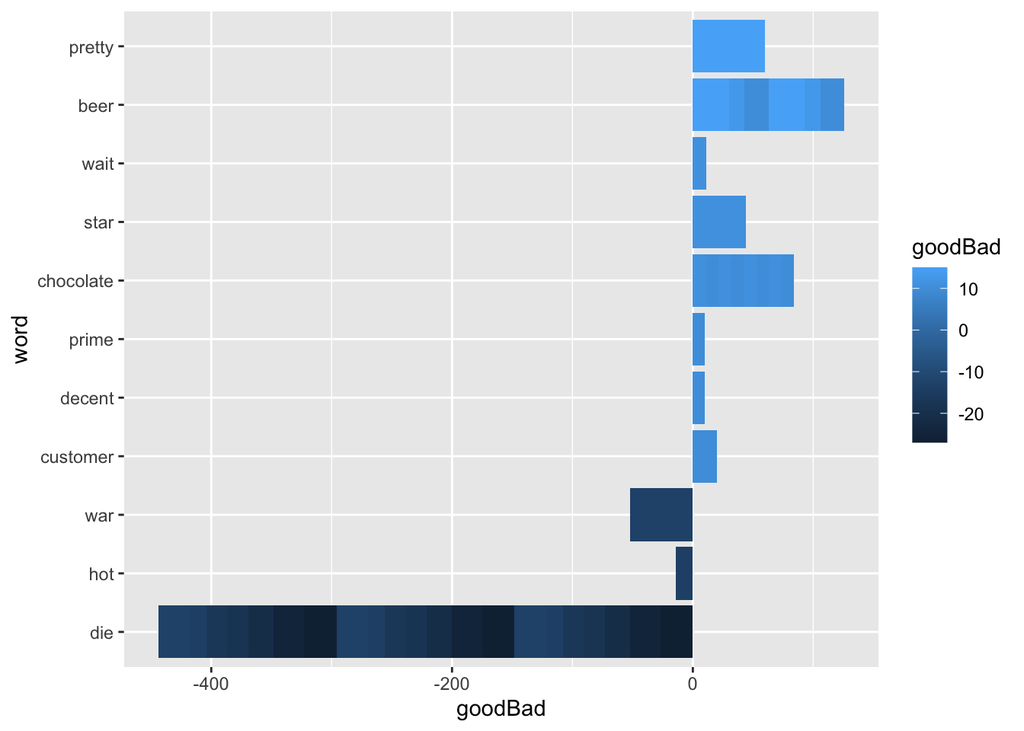

```r
rbind(top_n(xx, 25), top_n(xx, -25)) %>% mutate(word=reorder(word,goodBad)) %>% ggplot(aes(word, goodBad, fill=goodBad)) +geom_col()+coord_flip()
```

```r
#AFINN carries a numeric value for positive/negative sentiment -- how would you use these


#rSenti_afinn<-rrTokens %>% inner_join(get_sentiments("afinn"), by="word") %>% summarise(totOcc=sum(n)) %>% arrange(value, desc(totOcc))

rrSenti_afinn<-rrTokens %>% inner_join(get_sentiments("afinn"), by="word") %>% group_by (word, value) %>% summarise(totOcc=sum(n)) %>% arrange(value, desc(totOcc))
xx <- rrSenti_afinn %>% mutate(totOcc=ifelse(value > 0, totOcc, -totOcc))
```

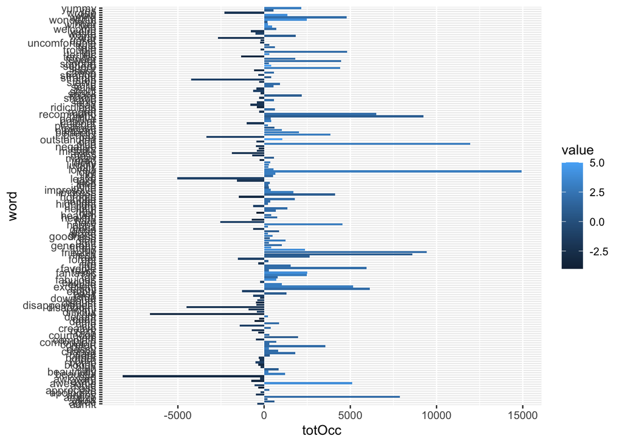

```r
rbind(top_n(xx, 25), top_n(xx, -25)) %>% mutate(word=reorder(word,totOcc)) %>% ggplot(aes(word, totOcc, fill=value)) +geom_col()+coord_flip()
```

### How many matching terms are there for each of the dictionaries?

**AFINN** Match Unique Words

**For the AFINN dictionary we found a total of 173 total matching words**

```r
AFINNMatchUniqueWords <- unique(rrSenti_afinn$word)
```

**Analysis by review sentiment. So far, we have analyzed overall sentiment across reviews, now let’s look into sentiment by review and see how that relates to review’s star ratings**

Bing Dictionary

```r
#summarise positive/negative sentiment words per review
revSenti_bing <- rrSenti_bing %>% group_by(review_id, stars) %>% summarise(nwords=n(),posSum=sum(sentiment=='positive'), negSum=sum(sentiment=='negative'))
```

```r
#calculate sentiment score based on proportion of positive, negative words
revSenti_bing<- revSenti_bing %>% mutate(posProp=posSum/nwords, negProp=negSum/nwords)
revSenti_bing<- revSenti_bing %>% mutate(sentiScore=posProp-negProp)
```

Here we are doing the agreggation of the scores and getting the average positive and negative for each star

```r
#Do review start ratings correspond to the the positive/negative sentiment words
revSenti_bing %>% group_by(stars) %>% summarise(avgPos=mean(posProp), avgNeg=mean(negProp), avgSentiSc=mean(sentiScore))
```

|  | stars | avgPos | avgNeg | avgSentiSc |
| --- | --- | --- | --- | --- |
| 1 | 1 | 0.3144588 | 0.6855412 | -0.37108246 |
| 2 | 2 | 0.4864232 | 0.5135768 | -0.02715366 |
| 3 | 3 | 0.6393501 | 0.3606499 | 0.27870024 |
| 4 | 4 | 0.7778374 | 0.2221626 | 0.55567477 |
| 5 | 5 | 0.8450920 | 0.1549080 | 0.69018403 |

### Bing - For Bing the accuracy of prediction is 82.3%

```r
#we can consider reviews with 1 to 2 stars as positive, and this with 4 to 5 stars as negative
revSenti_bing <- revSenti_bing %>% mutate(hiLo=ifelse(stars<=2,-1, ifelse(stars>=4, 1, 0 )))
revSenti_bing <- revSenti_bing %>% mutate(pred_hiLo=ifelse(sentiScore >0, 1, -1))
#filter out the reviews with 3 stars, and get the confusion matrix for hiLo vs pred_hiLo
xx<-revSenti_bing %>% filter(hiLo!=0)
table(actual=xx$hiLo, predicted=xx$pred_hiLo )
```

```
##       predicted
## actual    -1     1
##     -1  4889  1959
##     1   3081 18627
```

```r
#accuracy
BingAccuracy <-mean(xx$hiLo==xx$pred_hiLo)
```

Affin Dictionary

```r
#with AFINN dictionary words....following similar steps as above, but noting that AFINN assigns negative to positive sentiment value for words matching the dictionary
#take the sum of sentiment value for words in a review?
rrSenti_afinn<- rrTokens %>% inner_join(get_sentiments("afinn"), by="word")

revSenti_afinn <- rrSenti_afinn %>% group_by(review_id, stars) %>% summarise(nwords=n(), sentiSum =sum(value))

revSenti_afinn %>% group_by(stars) %>% summarise(avgLen=mean(nwords), avgSenti=mean(sentiSum))
```

|  | stars | avgLen | avgSenti |
| --- | --- | --- | --- |
| 1 | 1 | 3.294036 | -1.635506 |
| 2 | 2 | 3.647896 | 1.078641 |
| 3 | 3 | 3.757944 | 3.324360 |
| 4 | 4 | 3.773533 | 5.540390 |
| 5 | 5 | 3.591123 | 6.335813 |

```r
#looking at the sentisum

revSenti_afinn <- rrSenti_afinn %>% group_by(review_id, stars) %>% summarise(nwords=n(), sentiSum =sum(value))
```

Can we classify reviews on high/low stats based on aggregated sentiment of words in the reviews. We can learn a model to predict hiLo ratings, from words in reviews

### Affin - For affin the accuracy of prediction is 82.1%

```r
#we can consider reviews with 1 to 2 stars as positive, and this with 4 to 5 stars as negative
revSenti_afinn <- revSenti_afinn %>% mutate(hiLo=ifelse(stars<=2,-1, ifelse(stars>=4, 1, 0 )))
revSenti_afinn <- revSenti_afinn %>% mutate(pred_hiLo=ifelse(sentiSum >0, 1, -1))
#filter out the reviews with 3 stars, and get the confusion matrix for hiLo vs pred_hiLo
xx<-revSenti_afinn %>% filter(hiLo!=0)
table(actual=xx$hiLo, predicted=xx$pred_hiLo )
```

```
##       predicted
## actual    -1     1
##     -1  4060  2635
##     1   2340 18895
```

```r
#accuracy
AffinAccuracy <-mean(xx$hiLo==xx$pred_hiLo)
```

### NRC - For nrc the accuracy of prediction is 50.04%

nrc dictionary

```r
rrSenti_nrc<-rrTokens %>% inner_join(get_sentiments("nrc"), by="word") %>%
group_by (word, stars, sentiment) %>% summarise(totOcc=sum(n)) %>%
arrange(sentiment, desc(totOcc))
#How many words are there for the different sentiment categories
rrSenti_nrc %>% group_by(sentiment) %>% summarise(count=n(), sumn=sum(totOcc))
```

|  | sentiment | count | sumn |
| --- | --- | --- | --- |
| 1 | anger | 225 | 24488 |
| 2 | anticipation | 400 | 65711 |
| 3 | disgust | 220 | 19965 |
| 4 | fear | 190 | 20985 |
| 5 | joy | 419 | 83704 |
| 6 | negative | 555 | 63341 |
| 7 | positive | 1023 | 160670 |
| 8 | sadness | 260 | 27032 |
| 9 | surprise | 235 | 29306 |
| 10 | trust | 525 | 79031 |

```r
#top few words for different sentiments
rrSenti_nrc %>% group_by(sentiment) %>% arrange(sentiment, desc(totOcc)) %>% top_n(10) %>% view()
rrSenti_nrc <- rrSenti_nrc %>% mutate(goodBad=ifelse(sentiment %in% c('anger', 'disgust', 'fear', 'sadness', 'negative'), -totOcc, ifelse(sentiment %in% c('positive', 'joy', 'anticipation', 'trust'), totOcc, 0)))
xx<-ungroup(rrSenti_nrc)
top_n(xx, -20)
```

| word | stars | sentiment | totOcc | goodBad |
| --- | --- | --- | --- | --- |
| bad | 1 | anger | 1381 | -1381 |
| hot | 4 | anger | 1008 | -1008 |
| bad | 1 | disgust | 1381 | -1381 |
| bad | 1 | fear | 1381 | -1381 |
| die | 5 | fear | 1181 | -1181 |
| die | 4 | fear | 999 | -999 |
| wait | 5 | negative | 1491 | -1491 |
| bad | 1 | negative | 1381 | -1381 |
| bite | 4 | negative | 1377 | -1377 |
| wait | 4 | negative | 1361 | -1361 |

[output cut: 10 more lines]

```r
top_n(xx, 20)
```

| word | stars | sentiment | totOcc | goodBad |
| --- | --- | --- | --- | --- |
| friendly | 5 | anticipation | 2213 | 2213 |
| pretty | 4 | anticipation | 1792 | 1792 |
| love | 5 | joy | 3987 | 3987 |
| delicious | 5 | joy | 3034 | 3034 |
| friendly | 5 | joy | 2213 | 2213 |
| love | 4 | joy | 2174 | 2174 |
| delicious | 4 | joy | 1847 | 1847 |
| pretty | 4 | joy | 1792 | 1792 |
| favorite | 5 | joy | 1651 | 1651 |
| love | 5 | positive | 3987 | 3987 |

[output cut: 11 more lines]

```r
#considering reviews with 1 to 2 stars as negative, and this with 4 to 5 stars as positive
rrSenti_nrc <- rrSenti_nrc %>% mutate(hiLo=ifelse(stars<=2,-1, ifelse(stars>=4, 1, 0 )))
rrSenti_nrc <- rrSenti_nrc %>% mutate(pred_hiLo=ifelse(goodBad > 0, 1, -1))
#filter out the reviews with 3 stars, and get the confusion matrix for hiLo vs pred_hiLo
xx<-rrSenti_nrc %>% filter(hiLo!=0)
table(actual=xx$hiLo, predicted=xx$pred_hiLo)
```

```
##       predicted
## actual  -1   1
##     -1 674 945
##     1  674 948
```

```r
#Accuracy
nrcAccuracy <- mean(xx$hiLo==xx$pred_hiLo)
```

### The accuracy of prediction for Bing and Affin are higher than nrc and are almost equal to each other.

```r
ModelsAccuracyC <- data.frame(BingAccuracy, AffinAccuracy, nrcAccuracy)
```

### **D) Develop models to predict review sentiment. For this, split the data randomly into training and test sets. To make run times manageable, you may take a smaller sample of reviews (minimum should be 10,000).**

### Bing - Learn a model to predict hiLo ratings, from words in reviews

```r
#use pivot_wider to convert to a dtm form where each row is for a review and columns correspond to words since we want to keep the stars column
revDTM_sentiBing <- rrSenti_bing %>% pivot_wider(id_cols = c(review_id,stars), names_from = word, values_from = tf_idf) %>% ungroup()
#Note the ungroup() at the end -- this is IMPORTANT; we have grouped based on (review_id, stars), and this grouping is retained by default, and can cause problems in the later steps

dim(revDTM_sentiBing)
```

```
## [1] 33244   260
```

```r
#filter out the reviews with stars=3, and calculate hiLo sentiment 'class'
revDTM_sentiBing <- revDTM_sentiBing %>% filter(stars!=3) %>% mutate(hiLo=ifelse(stars<=2, -1, 1)) %>% select(-stars)

#how many review with 1, -1 'class'
revDTM_sentiBing %>% group_by(hiLo) %>% tally()
```

|  | hiLo | n |
| --- | --- | --- |
| 1 | -1 | 6848 |
| 2 | 1 | 21708 |

```r
#replace all the NAs with 0
revDTM_sentiBing <- revDTM_sentiBing %>% replace(., is.na(.), 0)
revDTM_sentiBing$hiLo <- as.factor(revDTM_sentiBing$hiLo)
```

### Building the Random Forest Models

##Random Forest Bing Model The Bing model categorizes sentiments as either negative or positive. In order to prepare the data for the Bing model, the positive sentiments were scored as positive values and negative sentiments were scored as negative values. The neutral three-star reviews were filtered out of the data, with the five and four star reviews were given as high scores, while the two and one star reviews were given as negative/low scores. All NA’s were removed from the dataset and replaced with zeros.

```r
library(ranger)

#replace all the NAs with 0
revDTM_sentiBing<-revDTM_sentiBing %>% replace(., is.na(.), 0)

revDTM_sentiBing$hiLo<- as.factor(revDTM_sentiBing$hiLo)
```

```r
library(rsample)
library(ROSE)

set.seed(200)
revDTM_sentiBing_split<- initial_split(revDTM_sentiBing, 0.7)
revDTM_sentiBing_trn<- training(revDTM_sentiBing_split)
revDTM_sentiBing_tst<- testing(revDTM_sentiBing_split)


rfModelbing<-ranger(dependent.variable.name = "hiLo", data=revDTM_sentiBing_trn %>% select(-review_id), num.trees = 500, importance='permutation', probability = TRUE)
rfModelbing
```

```
## Ranger result
##
## Call:
##  ranger(dependent.variable.name = "hiLo", data = revDTM_sentiBing_trn %>%      select(-review_id), num.trees = 500, importance = "permutation",      probability = TRUE)
##
## Type:                             Probability estimation
## Number of trees:                  500
## Sample size:                      19990
## Number of independent variables:  258
## Mtry:                             16
## Target node size:                 10
## Variable importance mode:         permutation
## Splitrule:                        gini
## OOB prediction error (Brier s.):  0.09123896
```

```r
#which variables are important
importance(rfModelbing) %>% view()
```

```r
#Obtain predictions, and calculate performance
revSentiBing_predTrn<- predict(rfModelbing, revDTM_sentiBing_trn %>% select(-review_id))$predictions

revSentiBing_predTst<- predict(rfModelbing, revDTM_sentiBing_tst %>% select(-review_id))$predictions

table(actual=revDTM_sentiBing_trn$hiLo, preds=revSentiBing_predTrn[,2]>0.6976635)
```

```
##       preds
## actual FALSE  TRUE
##     -1  4466   332
##     1    966 14226
```

```r
table(actual=revDTM_sentiBing_tst$hiLo, preds=revSentiBing_predTst[,2]>0.6976635)
```

```
##       preds
## actual FALSE TRUE
##     -1  1613  437
##     1    833 5683
```

```r
# accuracy for training
pred = revSentiBing_predTrn[,2]>0.6976635
pred <- ifelse(pred=="TRUE",1,-1)
mean(revDTM_sentiBing_trn$hiLo == pred)
```

```
## [1] 0.9350675
```

```r
#mean(revDTM_sentiBing_tst$hiLo)
pred = revSentiBing_predTst[,2]>0.6976635
pred <- ifelse(pred=="TRUE",1,-1)

# accuracy for test
rf_bing_acc <- mean(revDTM_sentiBing_tst$hiLo == pred)
```

```r
library(pROC)
rocTrn <- roc(revDTM_sentiBing_trn$hiLo, revSentiBing_predTrn[,2], levels=c(-1, 1))
rocTst <- roc(revDTM_sentiBing_tst$hiLo, revSentiBing_predTst[,2], levels=c(-1, 1))
```

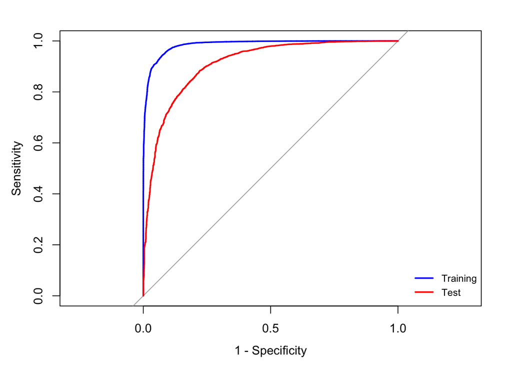

```r
plot.roc(rocTrn, col='blue', legacy.axes = TRUE)
plot.roc(rocTst, col='red', add=TRUE)
legend("bottomright", legend=c("Training", "Test"),
        col=c("blue", "red"), lwd=2, cex=0.8, bty='n')
```

###Developing a Ranger model for nrc

The Nrc model categorizes sentiments as different types of sentiments including positive, negative, joy, fear, anticipation, etc.. In order to prepare the data for the Nrc model, the “good” sentiments were combined (positive, joy, anticipation, trust) as positive scores and the “bad” sentiments were combined (anger, disgust, fear, sadness, negative) as negative scores. The neutral three-star reviews were filtered out of the data, with the five and four star reviews were given as high scores, while the two and one star reviews were given as negative/low scores. All NA’s were removed from the dataset and replaced with zeros.

```r
library(ranger)
```

```r
# library(rsample)
#
# set.seed(200)
# revDTM_sentinrc_split<- initial_split(revDTM_sentinrc, 0.7)
# revDTM_sentinrc_trn<- training(revDTM_sentinrc_split)
# revDTM_sentinrc_tst<- testing(revDTM_sentinrc_split)
#
# rfModelnrc<-ranger(dependent.variable.name = "hiLo", data=revDTM_sentinrc_trn %>% select(-review_id), num.trees = 500, importance='permutation', probability = TRUE)
#
# rfModelnrc
#
# #which variables are important
# importance(rfModelnrc) %>% view()
```

````r
# #Obtain predictions, and calculate performance
# revSentinrc_predTrn<- predict(rfModelnrc, revDTM_sentinrc_trn %>% select(-review_id))$predictions
#
# revSentinrc_predTst<- predict(rfModelnrc, revDTM_sentinrc_tst %>% select(-review_id))$predictions
#
# table(actual=revDTM_sentinrc_trn$hiLo, preds=revSentinrc_predTrn[,2]>0.5)
# table(actual=revDTM_sentinrc_tst$hiLo, preds=revSentinrc_predTst[,2]>0.5)
# ```
#
# ```{r eval=FALSE, warning=FALSE, include=FALSE}
# library(pROC)
#
# rocTrn <- roc(revDTM_sentinrc_trn$hiLo, revSentinrc_predTrn[,2], levels=c(-1, 1))
#
# rocTst <- roc(revDTM_sentinrc_tst$hiLo, revSentinrc_predTst[,2], levels=c(-1, 1))
#
# plot.roc(rocTrn, col='blue', legacy.axes = TRUE)
# plot.roc(rocTst, col='red', add=TRUE)
# legend("bottomright", legend=c("Training", "Test"),
#         col=c("blue", "red"), lwd=2, cex=0.8, bty='n')
#
#
# #Best threshold from ROC analyses
# bThr<-coords(rocTrn, "best", ret="threshold", transpose = FALSE)
#
# bThr
````

###Develop a ranger model for afinn

The Afinn model categorizes sentiments from -5 to +5. In order to prepare the data for the Afinn model, the positive sentiments were scored as positive values and negative sentiments were scored as negative values. The neutral three-star reviews were filtered out of the data, with the five and four star reviews were given as high scores, while the two and one star reviews were given as negative/low scores. All NA’s were removed from the dataset and replaced with zeros.

```r
rrSenti_afinn2<-rrTokens %>% inner_join(get_sentiments("afinn"), by="word") %>% group_by (review_id, word, value, stars) %>% summarise(totOcc=sum(n)) %>% arrange(value, desc(totOcc))
#Or, since we want to keep the stars column
revDTM_sentiafinn <- rrSenti_afinn2 %>%  pivot_wider(id_cols = c(review_id,stars), names_from = word, values_from = value)  %>% ungroup()

dim(revDTM_sentiafinn)
```

```
## [1] 32462   175
```

```r
#filter out the reviews with stars=3, and calculate hiLo sentiment 'class'
revDTM_sentiafinn <- revDTM_sentiafinn %>% filter(stars!=3) %>% mutate(hiLo=ifelse(stars<=2, -1, 1)) %>% select(-stars)

#how many review with 1, -1  'class'
revDTM_sentiafinn %>% group_by(hiLo) %>% tally()
```

|  | hiLo | n |
| --- | --- | --- |
| 1 | -1 | 6695 |
| 2 | 1 | 21235 |

##develop a random forest Afinn model to predict hiLo from the words in the reviews

```r
library(ranger)

#replace all the NAs with 0
revDTM_sentiafinn<-revDTM_sentiafinn %>% replace(., is.na(.), 0)

revDTM_sentiafinn$hiLo<- as.factor(revDTM_sentiafinn$hiLo)
```

```r
library(rsample)

set.seed(200)
revDTM_sentiafinn_split<- initial_split(revDTM_sentiafinn, 0.7)
revDTM_sentiafinn_trn<- training(revDTM_sentiafinn_split)
revDTM_sentiafinn_tst<- testing(revDTM_sentiafinn_split)

rfModelafinn<-ranger(dependent.variable.name = "hiLo", data=revDTM_sentiafinn_trn %>% select(-review_id), num.trees = 500, importance='permutation', probability = TRUE)
rfModelafinn
```

```
## Ranger result
##
## Call:
##  ranger(dependent.variable.name = "hiLo", data = revDTM_sentiafinn_trn %>%      select(-review_id), num.trees = 500, importance = "permutation",      probability = TRUE)
##
## Type:                             Probability estimation
## Number of trees:                  500
## Sample size:                      19551
## Number of independent variables:  173
## Mtry:                             13
## Target node size:                 10
## Variable importance mode:         permutation
## Splitrule:                        gini
## OOB prediction error (Brier s.):  0.1008229
```

```r
#which variables are important
importance(rfModelafinn) %>% view()
```

```r
#Obtain predictions, and calculate performance
revSentiafinn_predTrn<- predict(rfModelafinn, revDTM_sentiafinn_trn %>% select(-review_id))$predictions

revSentiafinn_predTst<- predict(rfModelafinn, revDTM_sentiafinn_tst %>% select(-review_id))$predictions

table(actual=revDTM_sentiafinn_trn$hiLo, preds=revSentiafinn_predTrn[,2]>0.7145345)
```

```
##       preds
## actual FALSE  TRUE
##     -1  4209   509
##     1   1534 13299
```

```r
table(actual=revDTM_sentiafinn_tst$hiLo, preds=revSentiafinn_predTst[,2]>0.7145345)
```

```
##       preds
## actual FALSE TRUE
##     -1  1557  420
##     1    973 5429
```

```r
library(pROC)
rocTrn <- roc(revDTM_sentiafinn_trn$hiLo, revSentiafinn_predTrn[,2], levels=c(-1, 1))
rocTst <- roc(revDTM_sentiafinn_tst$hiLo, revSentiafinn_predTst[,2], levels=c(-1, 1))
```

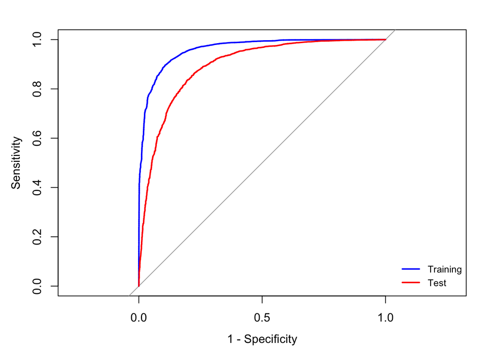

```r
plot.roc(rocTrn, col='blue', legacy.axes = TRUE)
plot.roc(rocTst, col='red', add=TRUE)
legend("bottomright", legend=c("Training", "Test"),
        col=c("blue", "red"), lwd=2, cex=0.8, bty='n')
```

```r
#Best threshold from ROC analyses
bThr<-coords(rocTrn, "best", ret="threshold", transpose = FALSE)
bThr
```

| threshold |
| --- |
| 0.7154824 |

```r
table(actual=revDTM_sentiafinn_trn$hiLo, preds=revSentiafinn_predTrn[,2]>.7145345)
```

```
##       preds
## actual FALSE  TRUE
##     -1  4209   509
##     1   1534 13299
```

```r
# accuracy for training
pred = revSentiafinn_predTrn[,2]>0.7145345
pred <- ifelse(pred=="TRUE",1,-1)
mean(revDTM_sentiafinn_trn$hiLo == pred)
```

```
## [1] 0.8955041
```

```r
# accuracy for test
#mean(revDTM_sentiBing_tst$hiLo)
pred = revSentiafinn_predTst[,2]>0.7145345
pred <- ifelse(pred=="TRUE",1,-1)
rf_afinn_acc <- mean(revDTM_sentiafinn_tst$hiLo == pred)
```

### Affin - Learn a model to predict hiLo ratings, from words in reviews

```r
#use pivot_wider to convert to a dtm form where each row is for a review and columns correspond to words since we want to keep the stars column
revDTM_sentiAfinn <- rrSenti_afinn %>% pivot_wider(id_cols = c(review_id,stars), names_from = word, values_from = value) %>% ungroup()
#Note the ungroup() at the end -- this is IMPORTANT; we have grouped based on (review_id, stars), and this grouping is retained by default, and can cause problems in the later steps

dim(revDTM_sentiAfinn)
```

```
## [1] 32462   175
```

```r
#filter out the reviews with stars=3, and calculate hiLo sentiment 'class'
revDTM_sentiAfinn <- revDTM_sentiAfinn %>% filter(stars!=3) %>% mutate(hiLo=ifelse(stars<=2, -1, 1)) %>% select(-stars)

#how many review with 1, -1 'class'
revDTM_sentiAfinn %>% group_by(hiLo) %>% tally()
```

|  | hiLo | n |
| --- | --- | --- |
| 1 | -1 | 6695 |
| 2 | 1 | 21235 |

```r
#replace all the NAs with 0
revDTM_sentiAfinn <- revDTM_sentiAfinn %>% replace(., is.na(.), 0)
revDTM_sentiAfinn$hiLo <- as.factor(revDTM_sentiAfinn$hiLo)
```

### Develop a naive-Bayes model - Bing https://www.rdocumentation.org/packages/e1071/versions/1.7-2/topics/naiveBayes

Accuracy for naive bayes bing dictionary is 66%

```r
library(rsample)

revDTM_sentiBing_split <- initial_split(revDTM_sentiBing, 0.8)

revDTM_sentiBing_trn <- training(revDTM_sentiBing_split)

revDTM_sentiBing_tst <- testing(revDTM_sentiBing_split)
```

```r
library(e1071)

nbModel1<-naiveBayes(hiLo ~ ., data=revDTM_sentiBing_trn %>% select(-review_id))

revSentiBing_NBpredTrn<-predict(nbModel1, revDTM_sentiBing_trn, type = "raw")
revSentiBing_NBpredTst<-predict(nbModel1, revDTM_sentiBing_tst, type = "raw")
str(revSentiBing_NBpredTst)
```

```
##  num [1:5711, 1:2] 1.00 5.59e-14 1.00 3.70e-04 7.77e-78 ...
##  - attr(*, "dimnames")=List of 2
##   ..$ : NULL
##   ..$ : chr [1:2] "-1" "1"
```

```r
view(revSentiBing_NBpredTst)


library(pROC)
#Area under the curve:
auc(as.numeric(revDTM_sentiBing_trn$hiLo), revSentiBing_NBpredTrn[,2])
```

```
## Area under the curve: 0.8041
```

```r
auc(as.numeric(revDTM_sentiBing_tst$hiLo), revSentiBing_NBpredTst[,2])
```

```
## Area under the curve: 0.8087
```

```r
#Confusion Matrix
table(actual= revDTM_sentiBing_trn$hiLo, predicted= revSentiBing_NBpredTrn[,2]>0.8)
```

```
##       predicted
## actual FALSE  TRUE
##     -1  4699   858
##     1   7012 10276
```

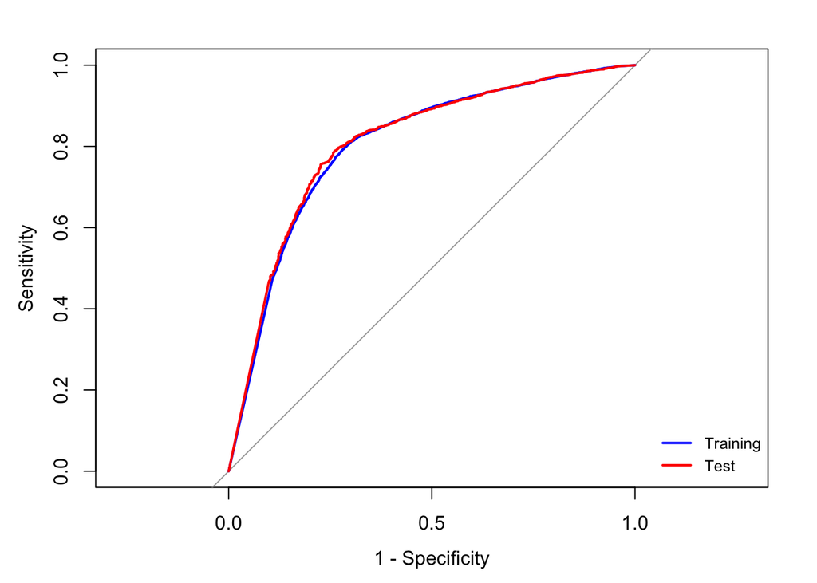

```r
ConfusionTable <- table(actual= revDTM_sentiBing_tst$hiLo, predicted= revSentiBing_NBpredTst[,2]>0.8)

# accuracy
#mean(revDTM_sentiBing_tst$hiLo)
pred = revSentiBing_NBpredTst[,2]>0.8
pred <- ifelse(pred=="TRUE",1,-1)
nb_bing_acc <- mean(revDTM_sentiBing_tst$hiLo == pred)

#ROC Curve
rocTrn <- roc(revDTM_sentiBing_trn$hiLo, revSentiBing_NBpredTrn[,2], levels=c(-1, 1))
rocTst <- roc(revDTM_sentiBing_tst$hiLo, revSentiBing_NBpredTst[,2], levels=c(-1, 1))
plot.roc(rocTrn, col='blue', legacy.axes = TRUE)
plot.roc(rocTst, col='red', add=TRUE)
legend("bottomright", legend=c("Training", "Test"), col=c("blue", "red"), lwd=2, cex=0.8, bty='n')
```

### Develop a naive-Bayes model - Affin

Accuracy for naive-bayes affin dictionary is 81%

```r
library(rsample)

revDTM_sentiAfinn_split<- initial_split(revDTM_sentiAfinn, 0.7)

revDTM_sentiAfinn_trn<- training(revDTM_sentiAfinn_split)

revDTM_sentiAfinn_tst<- testing(revDTM_sentiAfinn_split)
```

```r
library(e1071)

nbModel1<-naiveBayes(hiLo ~ ., data=revDTM_sentiAfinn_trn %>% select(-review_id))

revsentiafinn_NBpredTrn<-predict(nbModel1, revDTM_sentiAfinn_trn, type = "raw")
revsentiafinn_NBpredTst<-predict(nbModel1, revDTM_sentiAfinn_tst, type = "raw")

library(pROC)
#Area under the curve:
auc(as.numeric(revDTM_sentiAfinn_trn$hiLo), revsentiafinn_NBpredTrn[,2])
```

```
## Area under the curve: 0.8599
```

```r
auc(as.numeric(revDTM_sentiAfinn_tst$hiLo), revsentiafinn_NBpredTst[,2])
```

```
## Area under the curve: 0.8536
```

```r
#Confusion Matrix
table(actual= revDTM_sentiAfinn_trn$hiLo, predicted= revsentiafinn_NBpredTrn[,2]>0.8)
```

```
##       predicted
## actual FALSE  TRUE
##     -1  3179  1509
##     1   2106 12757
```

```r
table(actual= revDTM_sentiAfinn_tst$hiLo, predicted= revsentiafinn_NBpredTst[,2]>0.8)
```

```
##       predicted
## actual FALSE TRUE
##     -1  1320  687
##     1    853 5519
```

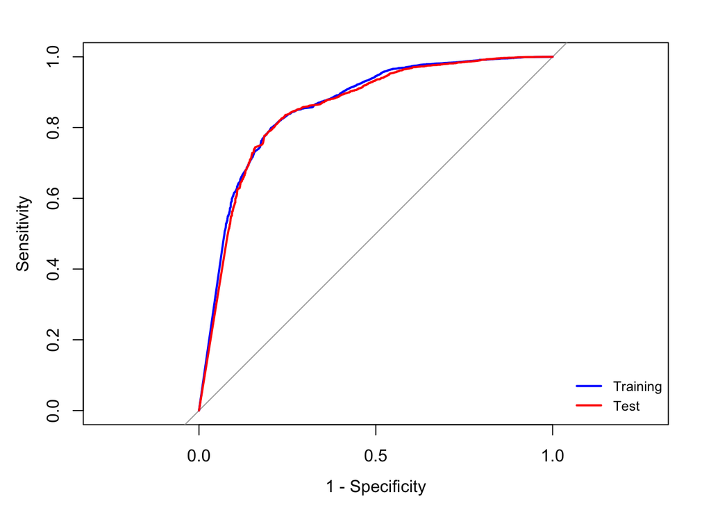

```r
# accuracy
pred = revsentiafinn_NBpredTst[,2]>0.8
pred <- ifelse(pred=="TRUE",1,-1)
nb_afinn_acc <- mean(revDTM_sentiAfinn_tst$hiLo == pred)

#ROC Curve
rocTrn <- roc(revDTM_sentiAfinn_trn$hiLo, revsentiafinn_NBpredTrn[,2], levels=c(-1, 1))
rocTst <- roc(revDTM_sentiAfinn_tst$hiLo, revsentiafinn_NBpredTst[,2], levels=c(-1, 1))
plot.roc(rocTrn, col='blue', legacy.axes = TRUE)
plot.roc(rocTst, col='red', add=TRUE)
legend("bottomright", legend=c("Training", "Test"), col=c("blue", "red"), lwd=2, cex=0.8, bty='n')
```

### Develop SVM model for afinn

```r
library(rsample)
revDTM_sentiAfinn_split<- initial_split(revDTM_sentiAfinn, 0.7)

revDTM_sentiAfinn_trn<- training(revDTM_sentiAfinn_split)

revDTM_sentiAfinn_tst<- testing(revDTM_sentiAfinn_split)

library(e1071)

#develop a SVM model on the sentiment dictionary terms

svmafinn <- svm(as.factor(hiLo) ~., data = revDTM_sentiAfinn_trn %>%select(-review_id),
kernel="radial", cost=1, scale=FALSE)

revDTM_predTrn_svm1afinn<-predict(svmafinn, revDTM_sentiAfinn_trn)
revDTM_predTst_svm1afinn<-predict(svmafinn, revDTM_sentiAfinn_tst)
table(actual= revDTM_sentiAfinn_trn$hiLo, predicted= revDTM_predTrn_svm1afinn)
```

```
##       predicted
## actual    -1     1
##     -1  2543  2141
##     1    478 14389
```

```r
system.time( svmafinn2 <- svm(as.factor(hiLo) ~., data = revDTM_sentiAfinn_trn
%>% select(-review_id), kernel="radial", cost=5, gamma=5, scale=FALSE) )
```

```
##    user  system elapsed
##  58.404   0.191  58.608
```

```r
revDTM_predTrn_svm2<-predict(svmafinn2, revDTM_sentiAfinn_trn)
table(actual= revDTM_sentiAfinn_trn$hiLo, predicted= revDTM_predTrn_svm2)
```

```
##       predicted
## actual    -1     1
##     -1  3954   730
##     1    235 14632
```

```r
revDTM_predTst_svm2<-predict(svmafinn2, revDTM_sentiAfinn_tst)
table(actual= revDTM_sentiAfinn_tst$hiLo, predicted= revDTM_predTst_svm2)
```

```
##       predicted
## actual   -1    1
##     -1  382 1629
##     1   149 6219
```

```r
svm_afinn_acc <- mean(revDTM_sentiAfinn_tst$hiLo == revDTM_predTst_svm2)
```

### Develop SVM model for Bing

```r
library(rsample)
library(ROSE)

#replace all the NAs with 0
revDTM_sentiBing<-revDTM_sentiBing %>% replace(., is.na(.), 0)

revDTM_sentiBing$hiLo<- as.factor(revDTM_sentiBing$hiLo)

revDTM_sentiBing_split<- initial_split(revDTM_sentiBing, 0.7)
revDTM_sentiBing_trn<- training(revDTM_sentiBing_split)
revDTM_sentiBing_tst<- testing(revDTM_sentiBing_split)
#develop a SVM model on the sentiment dictionary terms
svmBing <- svm(as.factor(hiLo) ~., data = revDTM_sentiBing_trn %>%select(-review_id),
kernel="radial", cost=1, scale=FALSE)

revDTM_predTrn_svm1Bing<-predict(svmBing, revDTM_sentiBing_trn)
revDTM_predTst_svm1Bing<-predict(svmBing, revDTM_sentiBing_tst)
table(actual= revDTM_sentiBing_trn$hiLo, predicted= revDTM_predTrn_svm1Bing)
```

```
##       predicted
## actual    -1     1
##     -1    32  4683
##     1      0 15275
```

```r
table(actual= revDTM_sentiBing_tst$hiLo, predicted= revDTM_predTst_svm1Bing)
```

```
##       predicted
## actual   -1    1
##     -1    9 2124
##     1     1 6432
```

### Develop SVM model on broader set of terms

```r
# sample_size = 10000
#
# revDTM_split<- initial_split(revDTM, 0.5)
# revDTM_trn<- training(revDTM_split)
# revDTM_tst<- testing(revDTM_split)
#
# #develop a SVM model on the sentiment dictionary terms
# svmM1 <- svm(as.factor(hiLo) ~., data = revDTM_trn %>%select(-review_id),
# kernel="radial", cost=1, scale=FALSE)
```

```r
# revDTM_predTrn_svm1broad<-predict(svmM1, revDTM_trn)
# revDTM_predTst_svm1broad<-predict(svmM1, revDTM_tst)
# table(actual= revDTM_trn$hiLo, predicted= revDTM_predTrn_svm1broad)
```

[output not shown]